# 2. Construct the potential landscapes from simulation results

Jingmeng Cui

```r
library(simlandr)
```

# Introduction

Here comes the central purpose of `simlandr`: constructing the potential landscapes from simulation results.

The landscape function is calculated based on the steady-state distribution of the system:

$$U = -\ln P_\textrm{SS}$$

My colleagues and I recently wrote some papers about the theoretical background of this method. You can find them at https://doi.org/10.1080/00273171.2022.2119927 or https://osf.io/pzva3.

`simlandr` provides a set of tools to construct 2d, 3d, and 4d landscapes from single or multiple simulation results. These methods will be illustrated in the following sections.

Frequently used parameters for the family of landscape functions:

`x`,`y`,`z`,`rols`,`cols`,`fr`: the variable names for plot dimensions; `from`,`to` (for 2d landscapes), `lims` (for 3d and 4d landscapes): the range of axes; `adjust` (for 2d landscapes), `h` (for 3d and 4d landscapes): the level of smoothness; `Umax`: the maximum displayed value of potential.

# Single simulation landscape

The landscapes in this section are only from a single simulation. We first make a simulation series for illustration.

```r
single_test <- sim_fun_test(
  arg1 = list(ele1 = 1),
  arg2 = list(ele2 = 1, ele3 = 0)
)
```

The result of the landscape functions is a `landscape` object, which contains the landscape plot as well as the smooth distributions that are used to calculate the landscapes. Plots without z-axis are built with `ggplot2` package, while plots with z-axis are built with `plotly` package. These plots can also be modified using `ggplot2` or `plotly` functions.

Use `autoplot(l)` to access ggplot representations and `plotly_ld(l)` to access interactive plotly landscapes.

Below are the examples of available plots. The meaning of the parameters can be found on the helping page of each function.

## 2d (x, y) plot

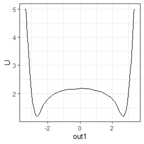

```r
l_single_2d <- make_2d_static(single_test, x = "out1")
autoplot(l_single_2d)
```

## 3d (x, y, z) or (x, y, color) plot

```r
l_single_3d <- make_3d_static(single_test, x = "out1", y = "out2")
```

```r
# This chunk will only run when building with pkgdown
plotly_ld(l_single_3d)
```

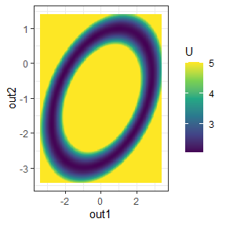

```r
autoplot(l_single_3d)
```

## 4d (x, y, z, color) plot

```r
# This chunk will only run when building with pkgdown
l_single_4d <- make_4d_static(single_test, x = "out1", y = "out2", z = "out3")
plotly_ld(l_single_4d) %>% plotly::layout(scene = list(zaxis = list(range = c(-3, 3))))
```

# Multiple simulation landscape

The landscapes in the section are built from batch simulation results. The following two data sets will be used to illustrate the functions. The difference is that `batch_test_result` only contains one varying parameter, whereas `batch_test_result2` contains two.

```r
batch_test <- new_arg_set()

batch_test <- batch_test %>%
  add_arg_ele("arg2", "ele3", 0.2, 0.5, 0.1)

batch_test_grid <- make_arg_grid(batch_test)

batch_test_result <- batch_simulation(batch_test_grid, sim_fun_test,
  default_list = list(
    arg1 = list(ele1 = 0),
    arg2 = list(ele2 = 0, ele3 = 0)
  ),
  bigmemory = FALSE
)
batch_test_result
```

```
#> Output(s) from 4 simulations.
```

```r
batch_test2 <- new_arg_set()
batch_test2 <- batch_test2 %>%
  add_arg_ele("arg1", "ele1", 0.2, 0.6, 0.2) %>%
  add_arg_ele("arg2", "ele2", 0.2, 0.6, 0.2)
batch_test_grid2 <- make_arg_grid(batch_test2)

batch_test_result2 <- batch_simulation(batch_test_grid2, sim_fun_test,
  default_list = list(
    arg1 = list(ele1 = 0),
    arg2 = list(ele2 = 0, ele3 = 0)
  ),
  bigmemory = FALSE
)
batch_test_result2
```

```
#> Output(s) from 9 simulations.
```

Below are the examples of available plots.

## 2d (x, y) plot series with one varying parameter or plot matrix with two varying parameters

```r
l_batch_2d_m1 <- make_2d_matrix(batch_test_result, x = "out1", cols = "ele3")
```

```
#> Wrangling the data...
#> Making the plots...
```

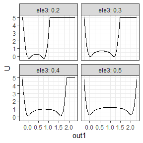

```r
autoplot(l_batch_2d_m1)
```

```r
l_batch_2d_m2 <- make_2d_matrix(batch_test_result2, x = "out1", rows = "ele1", cols = "ele2")
```

```
#> Wrangling the data...
#> Making the plots...
```

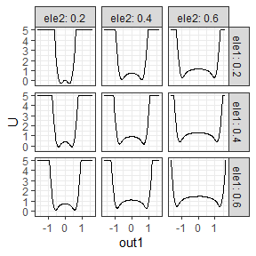

```r
autoplot(l_batch_2d_m2)
```

## 3d (x, y, color) plot series with one varying parameter or plot matrix with two varying parameters

```r
l_batch_3d_m1 <- make_3d_matrix(batch_test_result, x = "out1", y = "out2", cols = "ele3")
```

```
#> Wrangling the data...
#> Making the plots...
```

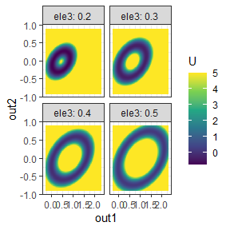

```r
autoplot(l_batch_3d_m1)
```

```r
l_batch_3d_m2 <- make_3d_matrix(batch_test_result2, x = "out1", y = "out2", rows = "ele1", cols = "ele2")
```

```
#> Wrangling the data...
#> Making the plots...
```

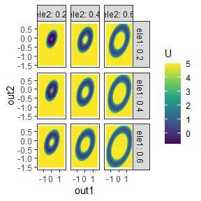

```r
autoplot(l_batch_3d_m2)
```

## 3d (x, y, z) or (x, y, color) animation and 3d (x, y, color) plot series with one varying parameter

*This part is computational and storage expensive thus not evaluated in the released vignette. You can run it on your device to see how the function produces animations. `gifski` package is needed to show the 3d (x, y, color) animation.*

```r
l_batch_3d_a <- make_3d_animation(batch_test_result, x = "out1", y = "out2", fr = "ele3")

plotly_ld(l_batch_3d_a)
autoplot(l_batch_3d_a)
```